# Conley Fisheries Case

Author

Jamison Orton

Published

October 9, 2026

## R Packages

```r
library(tidyverse)
options(pillar.sigfig = 5)
```

## Q1

```r
# Set the seed once before simulating
set.seed(123)

# Define n
n <- 1000

# Empty data frame for 1000 simulated days
data <- data.frame(
  day = seq(1:n),
  demand = sample(
    c(0, 1000, 2000, 3000, 4000, 5000, 6000),
    size = n,
    replace = TRUE,
    prob = c(0.02, 0.03, 0.05, 0.08, 0.33, 0.29, 0.20)
  ),
  quantity = NA,
  price = rnorm(n, mean = 3.65, sd = 0.2),
  cost = 10000,
  earnings = NA
)
data$quantity <- if_else(data$demand > 3500, 3500, data$demand)
data$earnings <- data$quantity * data$price - data$cost
```

### Plot simulated earnings at Rockport.

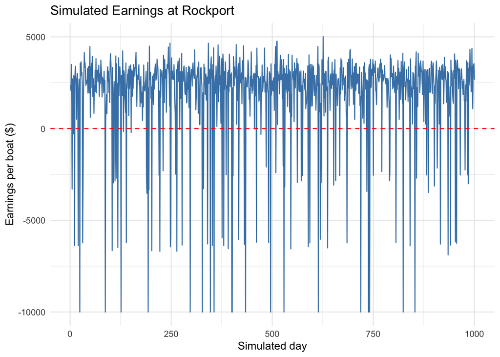

```r
ggplot(data, aes(x = day, y = earnings)) +
  geom_line(color = "steelblue") +
  geom_hline(yintercept = 0, color = "red", linetype = "dashed") +
  labs(
    title = "Simulated Earnings at Rockport",
    x = "Simulated day",
    y = "Earnings per boat ($)"
  ) +
  theme_minimal()
```

## Q2

### Earnings at Gloucester are fixed at $1375 ($3.25 x 3500 - $10,000). What is P(F > 1375) at Rockport? Write down the answer.

```r
mean(data$earnings > 1375)
```

```
[1] 0.826
```

P(F > 1375) = 0.826

## Q3

### What is the probability that Mr. Conley will lose money? We can express this as P(F < 0). Write down the answer.

```r
mean(data$earnings < 0)
```

```
[1] 0.099
```

P(F < 0) = 0.099

## Q4

### What is the mean of F? Write down the answer.

```r
mean(data$earnings)
```

```
[1] 1879.699
```

mean(F) = 1879.699

## Q5

### What is your advice to Mr. Conley? Write one paragraph in which you argue a position. In your answer please incorporate the quantitative details from your simulation, and consider in particular the trade-off between risk and reward.

I recommend that Mr. Conley sell in Rockport, given his willingness to accept risk for a higher return. In the simulation, Rockport earnings averaged $1,879.70 per boat per day, compared with Gloucester’s guaranteed $1,375, and exceeded Gloucester’s earnings on 82.6% of days. The risk is that Rockport earnings are much more variable (simulated standard deviation about $2,656.94) and the boat loses money on 9.9% of days. Overall, the higher average earnings and relatively low chance of a loss make Rockport the better choice under these assumptions.